# WUI Modeling

Wildland-urban interface and building ignition

The Wildland-Urban Interface (WUI) is where homes and structures meet wildland vegetation. This tutorial covers modeling building ignition during wildfires.

```julia
using Elmfire
using Plots
using Random
Random.seed!(42)
```

```
TaskLocalRNG()
```

## WUI Concepts

Buildings in the WUI can ignite from:

1. **Direct flame contact** - Fire reaches the structure
2. **Radiative heat** - Heat flux from nearby flames
3. **Embers (firebrands)** - Burning debris lands on combustibles
4. **Building-to-building spread** - Fire spreads between structures

## Creating Buildings

Define individual buildings:

```julia
# Create a wood-frame building
building = WUIBuilding{Float64}(
    1,              # ID
    30, 30;         # Grid coordinates
    construction_type = :wood,
    combustible_fraction = 0.7,
    ignition_temperature = 300.0
)

println("Building $(building.id) at ($(building.ix), $(building.iy))")
println("  Type: $(building.construction_type)")
println("  Combustible fraction: $(building.combustible_fraction)")
```

```
Building 1 at (30, 30)
  Type: wood
  Combustible fraction: 0.7
```

### Construction Types

Different construction materials have different vulnerability:

```julia
construction_types = [:wood, :masonry, :mixed]

for ctype in construction_types
    b = WUIBuilding{Float64}(1, 10, 10; construction_type = ctype)
    # Test ignition probability at same heat flux
    prob = building_ignition_probability(b, 30.0, 10.0)
    println("$ctype: Ignition probability = $(round(prob * 100, digits=1))%")
end
```

```
wood: Ignition probability = 100.0%
masonry: Ignition probability = 83.2%
mixed: Ignition probability = 99.8%
```

## Creating a WUI Grid

For simulations, create a grid of buildings:

```
Created 64 buildings
```

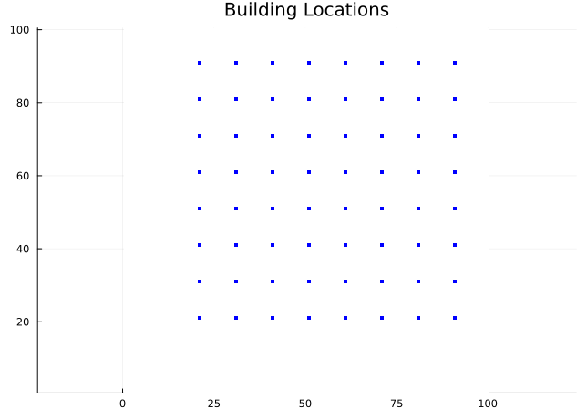

```julia
ncols, nrows = 100, 100

# Create a grid of buildings
buildings = create_building_grid(
    Float64,
    ncols, nrows,
    10,             # Building spacing (cells)
    3,              # Building footprint (cells)
    20, 20;         # Starting position
    construction_type = :wood
)

# Create WUI grid
wui_grid = WUIGrid{Float64}(buildings, ncols, nrows)

println("Created $(length(buildings)) buildings")

# Visualize building locations
building_map = zeros(ncols, nrows)
for b in buildings
    building_map[b.ix, b.iy] = 1
end

heatmap(building_map',
    title = "Building Locations",
    color = [:white, :blue],
    aspect_ratio = 1,
    colorbar = false
)
```

## Radiative Heat Flux

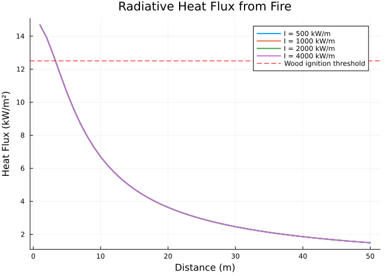

```julia
# Heat flux vs distance for different fireline intensities
distances = 1:1:50  # meters
intensities = [500, 1000, 2000, 4000]  # kW/m

p = plot(xlabel = "Distance (m)", ylabel = "Heat Flux (kW/m²)",
    title = "Radiative Heat Flux from Fire", legend = :topright)

for I in intensities
    fluxes = [compute_radiative_heat_flux(Float64(I), Float64(d), 5.0) for d in distances]
    plot!(p, distances, fluxes, label = "I = $I kW/m", linewidth = 2)
end

# Add ignition threshold
hline!(p, [12.5], linestyle = :dash, color = :red, label = "Wood ignition threshold")

p
```

## Building Ignition Probability

Ignition probability depends on heat flux and exposure time:

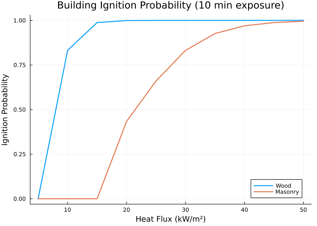

```julia
wood_building = WUIBuilding{Float64}(1, 10, 10; construction_type = :wood)
masonry_building = WUIBuilding{Float64}(2, 10, 10; construction_type = :masonry)

# Heat flux range
heat_fluxes = 5:5:50  # kW/m²
exposure_time = 10.0  # minutes

p = plot(xlabel = "Heat Flux (kW/m²)", ylabel = "Ignition Probability",
    title = "Building Ignition Probability (10 min exposure)",
    legend = :bottomright)

wood_probs = [building_ignition_probability(wood_building, Float64(q), exposure_time)
    for q in heat_fluxes]
masonry_probs = [building_ignition_probability(masonry_building, Float64(q), exposure_time)
    for q in heat_fluxes]

plot!(p, heat_fluxes, wood_probs, label = "Wood", linewidth = 2)
plot!(p, heat_fluxes, masonry_probs, label = "Masonry", linewidth = 2)

p
```

### Effect of Exposure Time

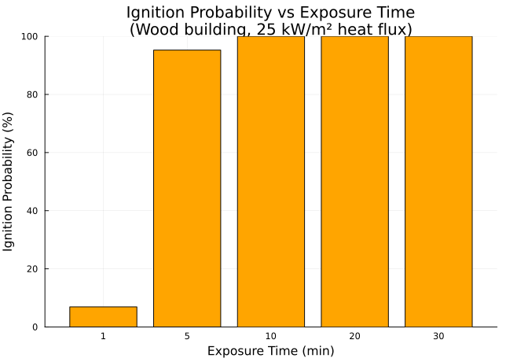

```julia
exposure_times = [1, 5, 10, 20, 30]  # minutes
heat_flux = 25.0  # kW/m²

probs = [building_ignition_probability(wood_building, heat_flux, Float64(t))
    for t in exposure_times]

bar(string.(exposure_times),
    probs .* 100,
    xlabel = "Exposure Time (min)",
    ylabel = "Ignition Probability (%)",
    title = "Ignition Probability vs Exposure Time\n(Wood building, 25 kW/m² heat flux)",
    legend = false,
    color = :orange
)
```

## Hamada Urban Fire Spread

The Hamada model describes fire spread between buildings:

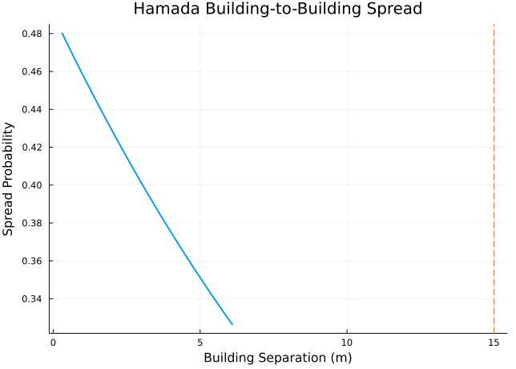

```julia
source = WUIBuilding{Float64}(1, 10, 10; construction_type = :wood)
params = HamadaParameters{Float64}(
    critical_separation = 15.0,  # meters
    wind_spread_factor = 1.5,
    ember_generation_rate = 0.1,
    base_spread_rate = 1.0
)

# Probability vs distance
separations = 1:1:20  # cells
cellsize = 1.0  # feet (small for test)

probs = Float64[]
for sep in separations
    target = WUIBuilding{Float64}(2, 10 + sep, 10; construction_type = :wood)
    prob = hamada_spread_probability(source, target, params, 10.0, 270.0, cellsize)
    push!(probs, prob)
end

# Convert cell distance to meters
dist_m = separations .* cellsize .* 0.3048

plot(dist_m, probs,
    xlabel = "Building Separation (m)",
    ylabel = "Spread Probability",
    title = "Hamada Building-to-Building Spread",
    linewidth = 2,
    legend = false
)
vline!([params.critical_separation], linestyle = :dash, label = "Critical separation")
```

## WUI Simulation Example

Simulate a fire approaching a residential area:

```
Created 15 buildings
```

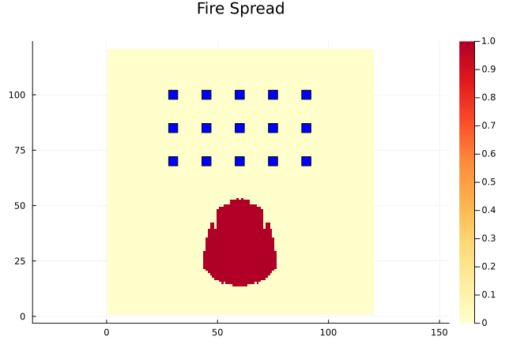

```julia
ncols, nrows = 120, 120
cellsize = 30.0

# Create fire state
state = FireState{Float64}(ncols, nrows, cellsize)
fuel_table = create_standard_fuel_table(Float64)

# Fuel: grass with houses in upper portion
fuel_ids = fill(1, ncols, nrows)

# Terrain
slope = zeros(Float64, ncols, nrows)
aspect = zeros(Float64, ncols, nrows)

# Weather - wind blowing north
weather = ConstantWeather{Float64}(
    wind_speed_mph = 12.0,
    wind_direction = 180.0,  # From south
    M1 = 0.05, M10 = 0.07, M100 = 0.09,
    MLH = 0.50, MLW = 0.80
)

# Create WUI with buildings in northern portion
buildings = WUIBuilding{Float64}[]
id = 0
for ix in 30:15:90
    for iy in 70:15:100
        id += 1
        ctype = rand([:wood, :wood, :masonry])  # 2/3 wood, 1/3 masonry
        push!(buildings, WUIBuilding{Float64}(id, ix, iy; construction_type = ctype))
    end
end

wui_grid = WUIGrid{Float64}(buildings, ncols, nrows)
println("Created $(length(buildings)) buildings")

# Ignite in southern portion
ignite!(state, 60, 20, 0.0)

# Run simulation and track WUI state
weather_interp = create_constant_interpolator(weather, ncols, nrows, cellsize)
rng = MersenneTwister(42)

# Simple simulation loop with WUI updates
t = 0.0
dt = 1.0
t_end = 60.0

while t < t_end
    # Update WUI state
    ignitions = update_wui_state!(wui_grid, state, weather, t, dt, rng)

    if !isempty(ignitions)
        for ig in ignitions
            println("Building $(ig.building_id) ignited at t=$(round(t, digits=1)) via $(ig.ignition_source)")
        end
    end

    t += dt
end

# Also run fire simulation
state2 = FireState{Float64}(ncols, nrows, cellsize)
ignite!(state2, 60, 20, 0.0)
simulate_uniform!(state2, 1, fuel_table, weather, 0.0, 0.0, 0.0, t_end)

# Visualize
p1 = heatmap(state2.burned',
    title = "Fire Spread",
    color = :YlOrRd,
    aspect_ratio = 1
)

# Add building markers
building_x = [b.ix for b in buildings]
building_y = [b.iy for b in buildings]
colors = [wui_grid.ignited[i] ? :red : :blue for i in 1:length(buildings)]

scatter!(p1, building_x, building_y,
    color = colors,
    markersize = 6,
    markershape = :square,
    label = false
)

p1
```

## WUI Statistics

Get summary statistics from the simulation:

```julia
stats = get_wui_statistics(wui_grid)

println("WUI Simulation Results:")
println("  Total buildings: $(stats.total_buildings)")
println("  Ignited buildings: $(stats.ignited_buildings)")
println("  Ignition fraction: $(round(stats.ignition_fraction * 100, digits=1))%")
println("  Mean ignition time: $(round(stats.mean_ignition_time, digits=1)) min")
println("  First ignition: $(round(stats.first_ignition_time, digits=1)) min")
println("  Last ignition: $(round(stats.last_ignition_time, digits=1)) min")
println("  Wood ignited: $(stats.wood_ignited)")
println("  Masonry ignited: $(stats.masonry_ignited)")
```

```
WUI Simulation Results:
  Total buildings: 15
  Ignited buildings: 0
  Ignition fraction: 0.0%
  Mean ignition time: 0.0 min
  First ignition: -1.0 min
  Last ignition: -1.0 min
  Wood ignited: 0
  Masonry ignited: 0
```

## View Factor Calculation

The view factor determines how much radiative heat a building receives:

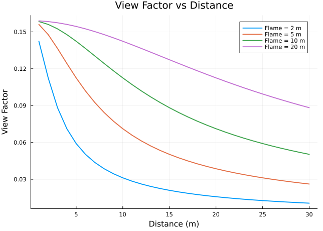

```julia
flame_heights = [2, 5, 10, 20]  # meters
distances = 1:1:30  # meters

p = plot(xlabel = "Distance (m)", ylabel = "View Factor",
    title = "View Factor vs Distance", legend = :topright)

for H in flame_heights
    vfs = [compute_view_factor(Float64(H), Float64(d)) for d in distances]
    plot!(p, distances, vfs, label = "Flame = $H m", linewidth = 2)
end

p
```

## Defense Zone Effectiveness

Simulate different defensible space configurations:

```julia
# Test different buffer distances
buffer_distances = [0, 30, 60, 100]  # feet
results = []

for buffer in buffer_distances
    # Create scenario where fire approaches building
    state = FireState{Float64}(80, 80, 30.0)

    # Create fuel map with buffer zone
    fuel_ids = fill(4, 80, 80)  # Chaparral
    if buffer > 0
        buffer_cells = div(buffer, 30)
        # Clear area around building at (40, 60)
        for ix in max(1, 40-buffer_cells):min(80, 40+buffer_cells)
            for iy in max(1, 60-buffer_cells):min(80, 60+buffer_cells)
                fuel_ids[ix, iy] = 1  # Grass (lower intensity)
            end
        end
    end

    ignite!(state, 40, 20, 0.0)
    simulate!(state, fuel_ids, fuel_table, weather, slope, aspect, 0.0, 45.0)

    # Check if fire reached building location
    reached = state.burned[40, 60]
    intensity = state.fireline_intensity[40, 60]

    push!(results, (buffer, reached, intensity))
end

for (buf, reached, intensity) in results
    status = reached ? "REACHED (I=$(round(intensity, digits=0)) kW/m)" : "Did not reach"
    println("Buffer $(buf)ft: $status")
end
```

```
Buffer 0ft: Did not reach
Buffer 30ft: Did not reach
Buffer 60ft: Did not reach
Buffer 100ft: Did not reach
```

## Best Practices for WUI Modeling

1. **Building Data**: Use actual building footprints and construction types when available
2. **Defensible Space**: Model vegetation clearing around structures
3. **Ember Transport**: Enable spotting for long-range ignitions
4. **Ensemble Approach**: Run multiple scenarios to capture uncertainty
5. **Validation**: Compare with post-fire damage assessments

## Limitations

- Simplified building geometry (point representation)
- Uniform construction within building type
- No interior fire dynamics
- Limited suppression effects

For detailed structure loss modeling, consider coupling with dedicated WUI loss models.